# Loan Default Risk Analysis and Prediction Using R

Case study: predicting loan default with Logistic Regression and Random Forest

Gautam Raju | Introduction to Data Science Lab

25 October 2026

> **Reproducibility note:** Place `credit_risk_dataset.csv` in the same folder as this `.Rmd` file before knitting. The data path is relative, so the report runs on any computer. All tables, numbers and plots are regenerated when the report is knitted; they are not copied from the notebook. Small differences from the originally reported figures are possible if package versions differ.

# 1 Case Study Overview

## 1.1 Problem statement

Loan default creates financial risk for lenders. This case study explores borrower and loan characteristics associated with default and builds predictive models in R to estimate whether a loan is likely to default.

## 1.2 Objectives

- Clean and prepare the credit-risk dataset.
- Explore default patterns through tables and visualizations.
- Examine numerical correlations and categorical associations with loan status (chi-square tests).
- Train and evaluate Logistic Regression and Random Forest models on a stratified 80:20 train-test split.
- Compare the models using accuracy, precision, recall, F1-score, ROC curves and AUC.
- Examine Random Forest feature importance.
- Run a probability-threshold experiment and a class-weighted Random Forest experiment.
- Use LIME to inspect one individual Random Forest prediction.

# 2 Dataset

**Source:** Credit Risk Dataset on Kaggle - https://www.kaggle.com/datasets/laotse/credit-risk-dataset. The local file is `credit_risk_dataset.csv`.

The original file has 32,581 rows and 12 variables. The target is `loan_status`, where `0` denotes non-default and `1` denotes default.

| Variable | Description |
| --- | --- |
| `person_age` | Age of the borrower (years) |
| `person_income` | Annual income of the borrower |
| `person_home_ownership` | Home ownership status (RENT, OWN, MORTGAGE, OTHER) |
| `person_emp_length` | Employment length (years) |
| `loan_intent` | Purpose of the loan |
| `loan_grade` | Loan grade (A to G) |
| `loan_amnt` | Loan amount |
| `loan_int_rate` | Loan interest rate (%) |
| `loan_status` | Target: 0 = non-default, 1 = default |
| `loan_percent_income` | Loan amount as a fraction of income |
| `cb_person_default_on_file` | Historical default on file (Y/N) |
| `cb_person_cred_hist_length` | Credit history length (years) |

# 3 Setup and Data Import

## 3.1 Load required packages

All packages are loaded once, here, so every later chunk can rely on them.

```r
suppressPackageStartupMessages({
  library(randomForest)
  library(caret)
  library(pROC)
  library(lime)
  library(dplyr)
  library(ggplot2)
  library(corrplot)
})

cat("All packages loaded successfully.\n")
```

```
## All packages loaded successfully.
```

## 3.2 Import the dataset

```r
file_path <- "credit_risk_dataset.csv"

if (!file.exists(file_path)) {
  stop("Dataset not found. Place credit_risk_dataset.csv in the same folder as this R Markdown file, then knit again.")
}

loan_data <- read.csv(file_path, stringsAsFactors = FALSE)

cat("Dataset imported successfully.\n")
```

```
## Dataset imported successfully.
```

```r
cat("Rows:", nrow(loan_data), "\n")
```

```
## Rows: 32581
```

```r
cat("Columns:", ncol(loan_data), "\n")
```

```
## Columns: 12
```

```r
head(loan_data)
```

```
##   person_age person_income person_home_ownership person_emp_length loan_intent
## 1         22         59000                  RENT               123    PERSONAL
## 2         21          9600                   OWN                 5   EDUCATION
## 3         25          9600              MORTGAGE                 1     MEDICAL
## 4         23         65500                  RENT                 4     MEDICAL
## 5         24         54400                  RENT                 8     MEDICAL
## 6         21          9900                   OWN                 2     VENTURE
##   loan_grade loan_amnt loan_int_rate loan_status loan_percent_income
## 1          D     35000         16.02           1                0.59
## 2          B      1000         11.14           0                0.10
## 3          C      5500         12.87           1                0.57
## 4          C     35000         15.23           1                0.53
## 5          C     35000         14.27           1                0.55
## 6          A      2500          7.14           1                0.25
##   cb_person_default_on_file cb_person_cred_hist_length
## 1                         Y                          3
## 2                         N                          2
## 3                         N                          3
## 4                         N                          2
## 5                         Y                          4
## 6                         N                          2
```

# 4 Data Inspection and Cleaning

## 4.1 Initial inspection and summary statistics

```r
# Dataset dimensions
dim(loan_data)
```

```
## [1] 32581    12
```

```r
# Column names and data types
str(loan_data)
```

```
## 'data.frame':    32581 obs. of  12 variables:
##  $ person_age                : int  22 21 25 23 24 21 26 24 24 21 ...
##  $ person_income             : int  59000 9600 9600 65500 54400 9900 77100 78956 83000 10000 ...
##  $ person_home_ownership     : chr  "RENT" "OWN" "MORTGAGE" "RENT" ...
##  $ person_emp_length         : num  123 5 1 4 8 2 8 5 8 6 ...
##  $ loan_intent               : chr  "PERSONAL" "EDUCATION" "MEDICAL" "MEDICAL" ...
##  $ loan_grade                : chr  "D" "B" "C" "C" ...
##  $ loan_amnt                 : int  35000 1000 5500 35000 35000 2500 35000 35000 35000 1600 ...
##  $ loan_int_rate             : num  16 11.1 12.9 15.2 14.3 ...
##  $ loan_status               : int  1 0 1 1 1 1 1 1 1 1 ...
##  $ loan_percent_income       : num  0.59 0.1 0.57 0.53 0.55 0.25 0.45 0.44 0.42 0.16 ...
##  $ cb_person_default_on_file : chr  "Y" "N" "N" "N" ...
##  $ cb_person_cred_hist_length: int  3 2 3 2 4 2 3 4 2 3 ...
```

```r
# Summary statistics
summary(loan_data)
```

```
##    person_age     person_income     person_home_ownership person_emp_length
##  Min.   : 20.00   Min.   :   4000   Length   :32581       Min.   :  0.00
##  1st Qu.: 23.00   1st Qu.:  38500   N.unique :    4       1st Qu.:  2.00
##  Median : 26.00   Median :  55000   N.blank  :    0       Median :  4.00
##  Mean   : 27.73   Mean   :  66075   Min.nchar:    3       Mean   :  4.79
##  3rd Qu.: 30.00   3rd Qu.:  79200   Max.nchar:    8       3rd Qu.:  7.00
##  Max.   :144.00   Max.   :6000000                         Max.   :123.00
##                                                           NAs    :895
##     loan_intent        loan_grade      loan_amnt     loan_int_rate
##  Length   :32581   Length   :32581   Min.   :  500   Min.   : 5.42
##  N.unique :    6   N.unique :    7   1st Qu.: 5000   1st Qu.: 7.90
##  N.blank  :    0   N.blank  :    0   Median : 8000   Median :10.99
##  Min.nchar:    7   Min.nchar:    1   Mean   : 9589   Mean   :11.01
##  Max.nchar:   17   Max.nchar:    1   3rd Qu.:12200   3rd Qu.:13.47
##                                      Max.   :35000   Max.   :23.22
##                                                      NAs    :3116
##   loan_status     loan_percent_income cb_person_default_on_file
##  Min.   :0.0000   Min.   :0.0000      Length   :32581
##  1st Qu.:0.0000   1st Qu.:0.0900      N.unique :    2
##  Median :0.0000   Median :0.1500      N.blank  :    0
##  Mean   :0.2182   Mean   :0.1702      Min.nchar:    1
##  3rd Qu.:0.0000   3rd Qu.:0.2300      Max.nchar:    1
##  Max.   :1.0000   Max.   :0.8300
##
##  cb_person_cred_hist_length
##  Min.   : 2.000
##  1st Qu.: 3.000
##  Median : 4.000
##  Mean   : 5.804
##  3rd Qu.: 8.000
##  Max.   :30.000
##
```

```r
# Missing values per column
colSums(is.na(loan_data))
```

```
##                 person_age              person_income
##                          0                          0
##      person_home_ownership          person_emp_length
##                          0                        895
##                loan_intent                 loan_grade
##                          0                          0
##                  loan_amnt              loan_int_rate
##                          0                       3116
##                loan_status        loan_percent_income
##                          0                          0
##  cb_person_default_on_file cb_person_cred_hist_length
##                          0                          0
```

```r
# Target distribution
table(loan_data$loan_status)
```

```
##
##     0     1
## 25473  7108
```

## 4.2 Data quality checks: duplicates, outliers and unusual values

```r
# Number of exact duplicate rows
sum(duplicated(loan_data))
```

```
## [1] 165
```

```r
# Age
summary(loan_data$person_age)
```

```
##    Min. 1st Qu.  Median    Mean 3rd Qu.    Max.
##   20.00   23.00   26.00   27.73   30.00  144.00
```

```r
sum(loan_data$person_age > 80, na.rm = TRUE)
```

```
## [1] 7
```

```r
# Employment length
summary(loan_data$person_emp_length)
```

```
##    Min. 1st Qu.  Median    Mean 3rd Qu.    Max.     NAs
##    0.00    2.00    4.00    4.79    7.00  123.00     895
```

```r
sum(loan_data$person_emp_length > 50, na.rm = TRUE)
```

```
## [1] 2
```

```r
# Income
summary(loan_data$person_income)
```

```
##    Min. 1st Qu.  Median    Mean 3rd Qu.    Max.
##    4000   38500   55000   66075   79200 6000000
```

```r
# Loan amount
summary(loan_data$loan_amnt)
```

```
##    Min. 1st Qu.  Median    Mean 3rd Qu.    Max.
##     500    5000    8000    9589   12200   35000
```

```r
# Interest rate
summary(loan_data$loan_int_rate)
```

```
##    Min. 1st Qu.  Median    Mean 3rd Qu.    Max.     NAs
##    5.42    7.90   10.99   11.01   13.47   23.22    3116
```

## 4.3 Inspect unusual records

```r
# People older than 80
loan_data[
  loan_data$person_age > 80,
  c("person_age", "person_emp_length", "person_income")
]
```

```
##       person_age person_emp_length person_income
## 82           144                 4        250000
## 184          144                 4        200000
## 576          123                 2         80004
## 748          123                 7         78000
## 32298        144                12       6000000
## 32417         94                 1         24000
## 32507         84                 2         94800
```

```r
# Employment length above 50 years
loan_data[
  !is.na(loan_data$person_emp_length) &
    loan_data$person_emp_length > 50,
  c("person_age", "person_emp_length", "person_income")
]
```

```
##     person_age person_emp_length person_income
## 1           22               123         59000
## 211         21               123        192000
```

## 4.4 Remove duplicates and invalid values

```r
# Start from the original dataset
loan_clean <- loan_data

# Remove exact duplicate rows
loan_clean <- loan_clean[!duplicated(loan_clean), ]

# Remove ages above 100
loan_clean <- loan_clean[loan_clean$person_age <= 100, ]

# Remove employment lengths above 50, keeping missing values
loan_clean <- loan_clean[
  is.na(loan_clean$person_emp_length) |
    loan_clean$person_emp_length <= 50,
]

cat("Cleaning completed.\n")
```

```
## Cleaning completed.
```

```r
cat("Original rows:", nrow(loan_data), "\n")
```

```
## Original rows: 32581
```

```r
cat("Cleaned rows:", nrow(loan_clean), "\n")
```

```
## Cleaned rows: 32409
```

```r
cat("Columns:", ncol(loan_clean), "\n")
```

```
## Columns: 12
```

## 4.5 Verify the cleaned dataset

```r
# Confirm cleaned dimensions
dim(loan_clean)
```

```
## [1] 32409    12
```

```r
# Remaining missing values
colSums(is.na(loan_clean))
```

```
##                 person_age              person_income
##                          0                          0
##      person_home_ownership          person_emp_length
##                          0                        887
##                loan_intent                 loan_grade
##                          0                          0
##                  loan_amnt              loan_int_rate
##                          0                       3094
##                loan_status        loan_percent_income
##                          0                          0
##  cb_person_default_on_file cb_person_cred_hist_length
##                          0                          0
```

```r
# Check age range
summary(loan_clean$person_age)
```

```
##    Min. 1st Qu.  Median    Mean 3rd Qu.    Max.
##   20.00   23.00   26.00   27.73   30.00   94.00
```

```r
# Check employment length
summary(loan_clean$person_emp_length)
```

```
##    Min. 1st Qu.  Median    Mean 3rd Qu.    Max.     NAs
##   0.000   2.000   4.000   4.783   7.000  41.000     887
```

```r
# Confirm no duplicate rows remain
sum(duplicated(loan_clean))
```

```
## [1] 0
```

## 4.6 Convert categorical variables into factors

The target `loan_status` is given the levels `"0"` and `"1"` here, and that order is used consistently in every later chunk.

```r
loan_clean$person_home_ownership <- as.factor(loan_clean$person_home_ownership)
loan_clean$loan_intent           <- as.factor(loan_clean$loan_intent)
loan_clean$loan_grade            <- as.factor(loan_clean$loan_grade)
loan_clean$cb_person_default_on_file <- as.factor(loan_clean$cb_person_default_on_file)
loan_clean$loan_status           <- factor(loan_clean$loan_status, levels = c(0, 1))

str(loan_clean)
```

```
## 'data.frame':    32409 obs. of  12 variables:
##  $ person_age                : int  21 25 23 24 21 26 24 24 21 22 ...
##  $ person_income             : int  9600 9600 65500 54400 9900 77100 78956 83000 10000 85000 ...
##  $ person_home_ownership     : Factor w/ 4 levels "MORTGAGE","OTHER",..: 3 1 4 4 3 4 4 4 3 4 ...
##  $ person_emp_length         : num  5 1 4 8 2 8 5 8 6 6 ...
##  $ loan_intent               : Factor w/ 6 levels "DEBTCONSOLIDATION",..: 2 4 4 4 6 2 4 5 6 6 ...
##  $ loan_grade                : Factor w/ 7 levels "A","B","C","D",..: 2 3 3 3 1 2 2 1 4 2 ...
##  $ loan_amnt                 : int  1000 5500 35000 35000 2500 35000 35000 35000 1600 35000 ...
##  $ loan_int_rate             : num  11.14 12.87 15.23 14.27 7.14 ...
##  $ loan_status               : Factor w/ 2 levels "0","1": 1 2 2 2 2 2 2 2 2 2 ...
##  $ loan_percent_income       : num  0.1 0.57 0.53 0.55 0.25 0.45 0.44 0.42 0.16 0.41 ...
##  $ cb_person_default_on_file : Factor w/ 2 levels "N","Y": 1 1 1 2 1 1 1 1 1 1 ...
##  $ cb_person_cred_hist_length: int  2 3 2 4 2 3 4 2 3 4 ...
```

# 5 Exploratory Data Analysis (EDA)

## 5.1 Distribution of loan default status

```r
# Counts
table(loan_clean$loan_status)
```

```
##
##     0     1
## 25321  7088
```

```r
# Percentages
round(prop.table(table(loan_clean$loan_status)) * 100, 2)
```

```
##
##     0     1
## 78.13 21.87
```

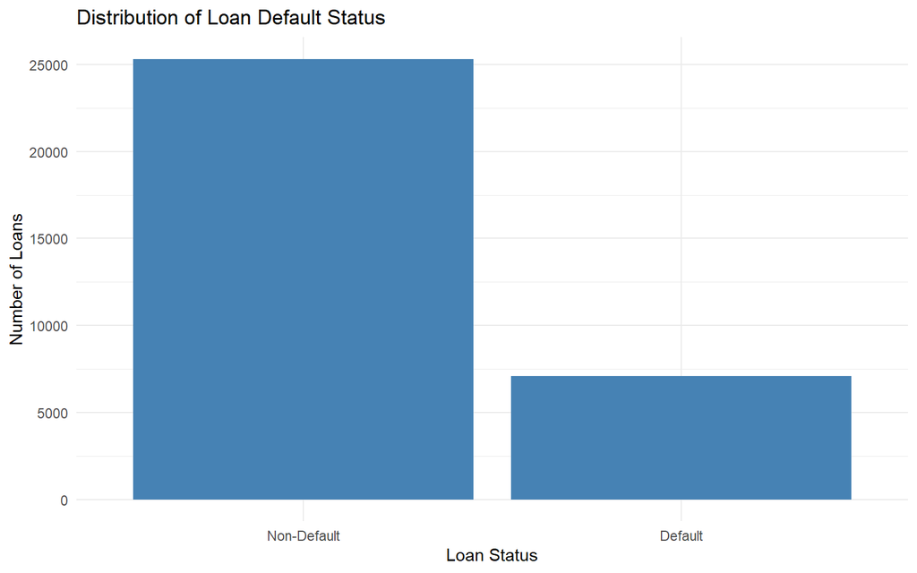

```r
# Plot
ggplot(loan_clean, aes(x = loan_status)) +
  geom_bar(fill = "steelblue") +
  labs(
    title = "Distribution of Loan Default Status",
    x = "Loan Status",
    y = "Number of Loans"
  ) +
  scale_x_discrete(labels = c("0" = "Non-Default", "1" = "Default")) +
  theme_minimal()
```

## 5.2 Default rate by loan grade

```r
grade_default <- loan_clean %>%
  group_by(loan_grade) %>%
  summarise(
    Total_Loans = n(),
    Defaults = sum(loan_status == "1", na.rm = TRUE),
    Default_Rate = mean(loan_status == "1", na.rm = TRUE) * 100,
    .groups = "drop"
  )

print(grade_default)
```

```
## # A tibble: 7 × 4
##   loan_grade Total_Loans Defaults Default_Rate
##   <fct>            <int>    <int>        <dbl>
## 1 A                10702     1066         9.96
## 2 B                10384     1695        16.3
## 3 C                 6436     1336        20.8
## 4 D                 3619     2137        59.0
## 5 E                  963      621        64.5
## 6 F                  241      170        70.5
## 7 G                   64       63        98.4
```

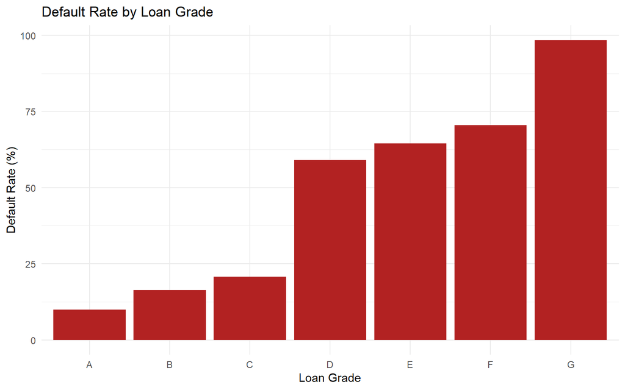

```r
ggplot(grade_default, aes(x = loan_grade, y = Default_Rate)) +
  geom_col(fill = "firebrick") +
  labs(
    title = "Default Rate by Loan Grade",
    x = "Loan Grade",
    y = "Default Rate (%)"
  ) +
  theme_minimal()
```

## 5.3 Income distribution by loan default status

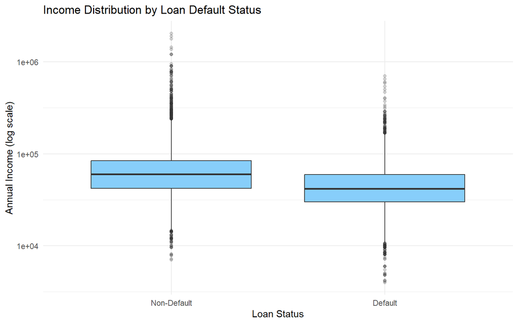

```r
ggplot(loan_clean, aes(x = loan_status, y = person_income)) +
  geom_boxplot(fill = "lightskyblue", outlier.alpha = 0.2) +
  labs(
    title = "Income Distribution by Loan Default Status",
    x = "Loan Status",
    y = "Annual Income (log scale)"
  ) +
  scale_x_discrete(labels = c("0" = "Non-Default", "1" = "Default")) +
  scale_y_log10() +
  theme_minimal()
```

## 5.4 Loan amount distribution by default status

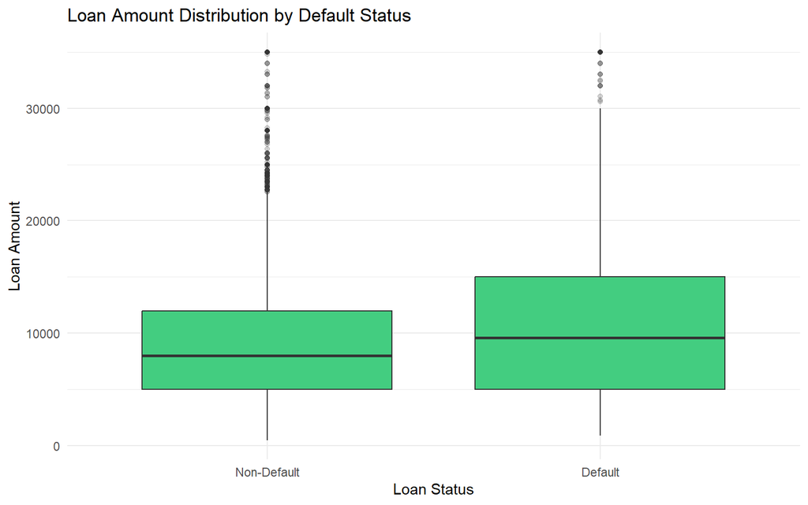

```r
ggplot(loan_clean, aes(x = loan_status, y = loan_amnt)) +
  geom_boxplot(fill = "seagreen3", outlier.alpha = 0.2) +
  labs(
    title = "Loan Amount Distribution by Default Status",
    x = "Loan Status",
    y = "Loan Amount"
  ) +
  scale_x_discrete(labels = c("0" = "Non-Default", "1" = "Default")) +
  theme_minimal()
```

## 5.5 Default rate by loan purpose

```r
purpose_default <- loan_clean %>%
  group_by(loan_intent) %>%
  summarise(
    Total_Loans = n(),
    Defaults = sum(loan_status == "1", na.rm = TRUE),
    Default_Rate = mean(loan_status == "1", na.rm = TRUE) * 100,
    .groups = "drop"
  )

print(purpose_default)
```

```
## # A tibble: 6 × 4
##   loan_intent       Total_Loans Defaults Default_Rate
##   <fct>                   <int>    <int>        <dbl>
## 1 DEBTCONSOLIDATION        5189     1488         28.7
## 2 EDUCATION                6409     1106         17.3
## 3 HOMEIMPROVEMENT          3594      940         26.2
## 4 MEDICAL                  6042     1617         26.8
## 5 PERSONAL                 5496     1093         19.9
## 6 VENTURE                  5679      844         14.9
```

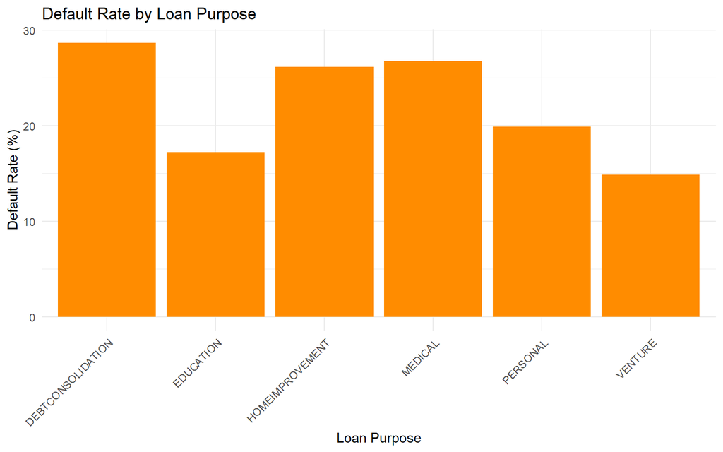

```r
ggplot(purpose_default, aes(x = loan_intent, y = Default_Rate)) +
  geom_col(fill = "darkorange") +
  labs(
    title = "Default Rate by Loan Purpose",
    x = "Loan Purpose",
    y = "Default Rate (%)"
  ) +
  theme_minimal() +
  theme(axis.text.x = element_text(angle = 45, hjust = 1))
```

## 5.6 Interest rate distribution by default status

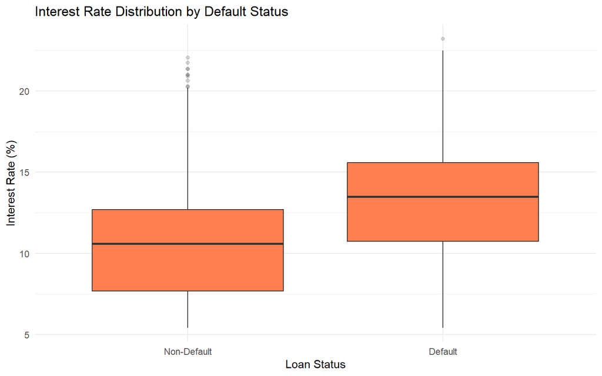

```r
ggplot(loan_clean, aes(x = loan_status, y = loan_int_rate)) +
  geom_boxplot(fill = "coral", na.rm = TRUE, outlier.alpha = 0.2) +
  labs(
    title = "Interest Rate Distribution by Default Status",
    x = "Loan Status",
    y = "Interest Rate (%)"
  ) +
  scale_x_discrete(labels = c("0" = "Non-Default", "1" = "Default")) +
  theme_minimal()
```

## 5.7 Loan-to-income ratio by default status

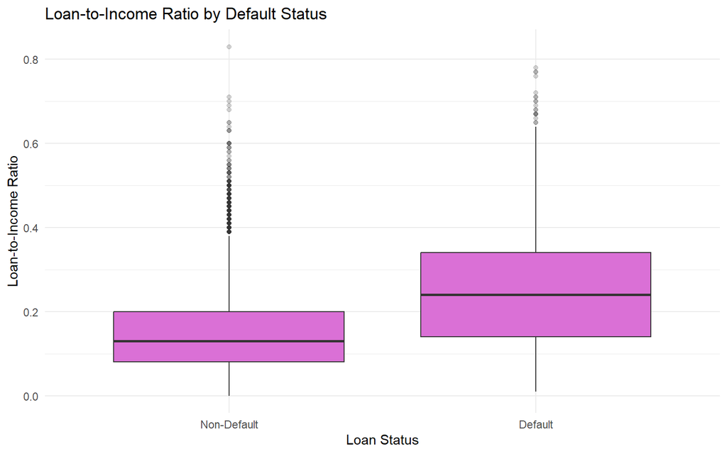

```r
ggplot(loan_clean, aes(x = loan_status, y = loan_percent_income)) +
  geom_boxplot(fill = "orchid", na.rm = TRUE, outlier.alpha = 0.2) +
  labs(
    title = "Loan-to-Income Ratio by Default Status",
    x = "Loan Status",
    y = "Loan-to-Income Ratio"
  ) +
  scale_x_discrete(labels = c("0" = "Non-Default", "1" = "Default")) +
  theme_minimal()
```

## 5.8 Previous default history vs current loan default

```r
default_history <- loan_clean %>%
  group_by(cb_person_default_on_file, loan_status) %>%
  summarise(Count = n(), .groups = "drop")

print(default_history)
```

```
## # A tibble: 4 × 3
##   cb_person_default_on_file loan_status Count
##   <fct>                     <fct>       <int>
## 1 N                         0           21761
## 2 N                         1            4919
## 3 Y                         0            3560
## 4 Y                         1            2169
```

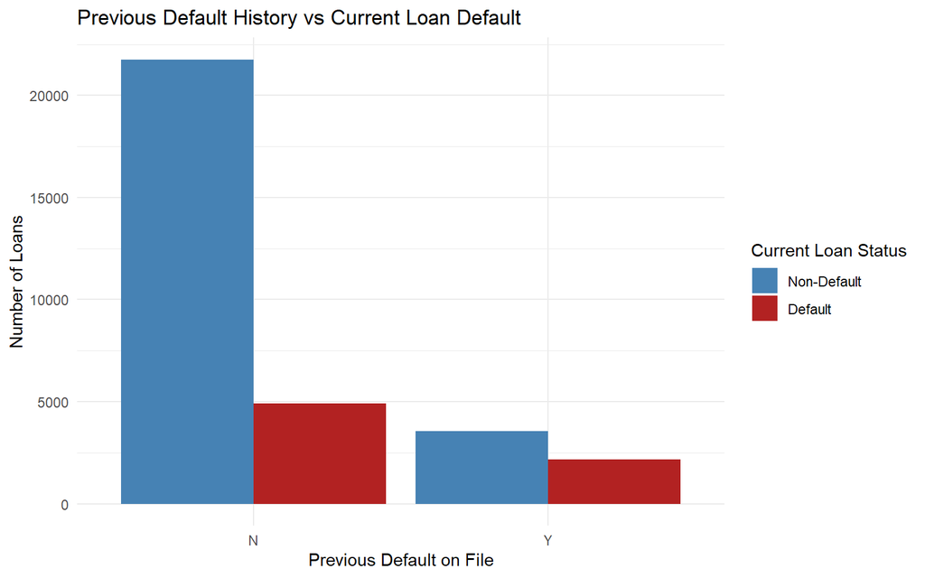

```r
ggplot(
  default_history,
  aes(x = cb_person_default_on_file, y = Count, fill = loan_status)
) +
  geom_col(position = "dodge") +
  labs(
    title = "Previous Default History vs Current Loan Default",
    x = "Previous Default on File",
    y = "Number of Loans",
    fill = "Current Loan Status"
  ) +
  scale_fill_manual(
    values = c("0" = "steelblue", "1" = "firebrick"),
    labels = c("0" = "Non-Default", "1" = "Default")
  ) +
  theme_minimal()
```

## 5.9 Default rate by home ownership

```r
home_default <- loan_clean %>%
  group_by(person_home_ownership) %>%
  summarise(
    Total_Loans = n(),
    Defaults = sum(loan_status == "1", na.rm = TRUE),
    Default_Rate = mean(loan_status == "1", na.rm = TRUE) * 100,
    .groups = "drop"
  )

print(home_default)
```

```
## # A tibble: 4 × 4
##   person_home_ownership Total_Loans Defaults Default_Rate
##   <fct>                       <int>    <int>        <dbl>
## 1 MORTGAGE                    13366     1687        12.6
## 2 OTHER                         106       33        31.1
## 3 OWN                          2563      192         7.49
## 4 RENT                        16374     5176        31.6
```

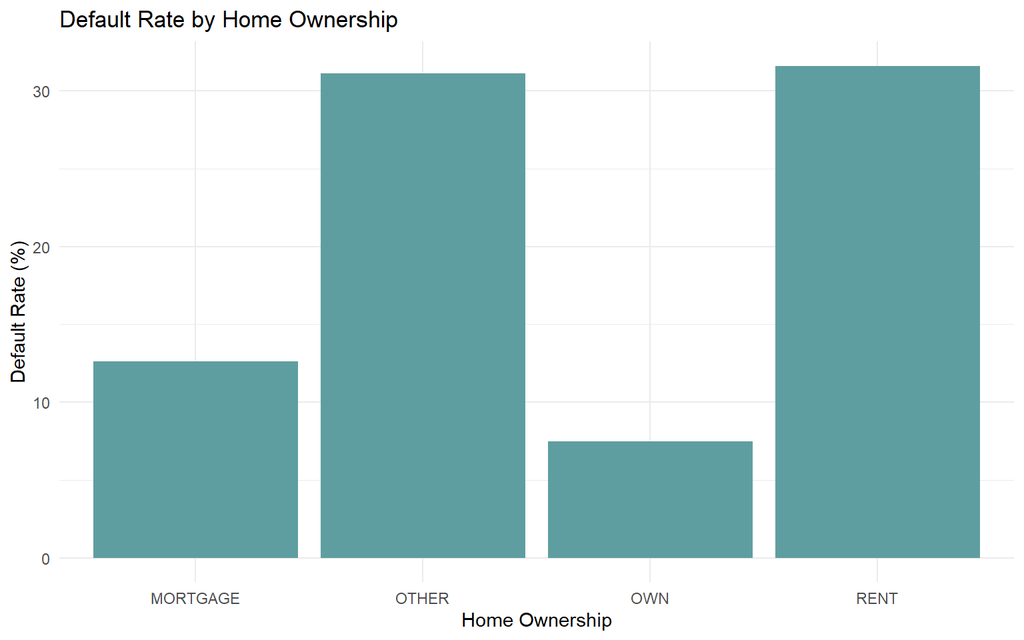

```r
ggplot(home_default, aes(x = person_home_ownership, y = Default_Rate)) +
  geom_col(fill = "cadetblue") +
  labs(
    title = "Default Rate by Home Ownership",
    x = "Home Ownership",
    y = "Default Rate (%)"
  ) +
  theme_minimal()
```

## 5.10 Default rate by employment length

```r
emp_default <- loan_clean %>%
  filter(!is.na(person_emp_length)) %>%
  mutate(
    Employment_Group = cut(
      person_emp_length,
      breaks = c(-1, 2, 5, 10, Inf),
      labels = c("0-2 Years", "3-5 Years", "6-10 Years", "10+ Years")
    )
  ) %>%
  group_by(Employment_Group) %>%
  summarise(
    Total_Loans = n(),
    Defaults = sum(loan_status == "1", na.rm = TRUE),
    Default_Rate = mean(loan_status == "1", na.rm = TRUE) * 100,
    .groups = "drop"
  )

print(emp_default)
```

```
## # A tibble: 4 × 4
##   Employment_Group Total_Loans Defaults Default_Rate
##   <fct>                  <int>    <int>        <dbl>
## 1 0-2 Years              10814     2933         27.1
## 2 3-5 Years               9229     1851         20.1
## 3 6-10 Years              8564     1550         18.1
## 4 10+ Years               2915      473         16.2
```

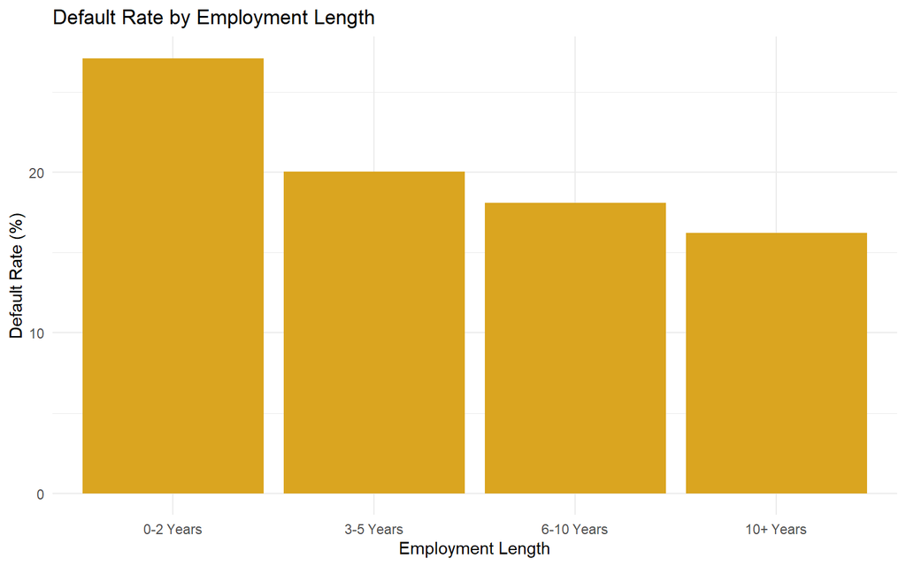

```r
ggplot(emp_default, aes(x = Employment_Group, y = Default_Rate)) +
  geom_col(fill = "goldenrod") +
  labs(
    title = "Default Rate by Employment Length",
    x = "Employment Length",
    y = "Default Rate (%)"
  ) +
  theme_minimal()
```

## 5.11 Age distribution by loan default status

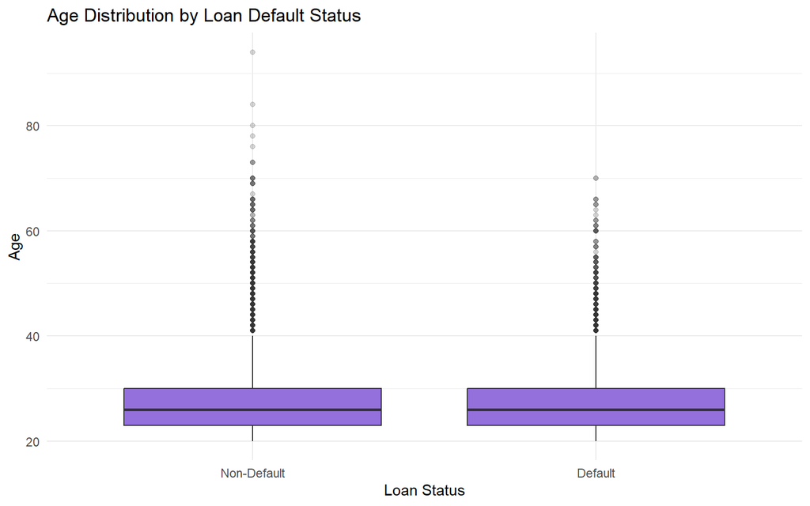

```r
ggplot(loan_clean, aes(x = loan_status, y = person_age)) +
  geom_boxplot(fill = "mediumpurple", outlier.alpha = 0.2) +
  labs(
    title = "Age Distribution by Loan Default Status",
    x = "Loan Status",
    y = "Age"
  ) +
  scale_x_discrete(labels = c("0" = "Non-Default", "1" = "Default")) +
  theme_minimal()
```

## 5.12 Correlation matrix of numerical variables

```r
numeric_data <- loan_clean %>%
  dplyr::select(
    person_age,
    person_income,
    person_emp_length,
    loan_amnt,
    loan_int_rate,
    loan_percent_income,
    cb_person_cred_hist_length
  )

cor_matrix <- cor(
  numeric_data,
  use = "pairwise.complete.obs",
  method = "pearson"
)

round(cor_matrix, 3)
```

```
##                            person_age person_income person_emp_length loan_amnt
## person_age                      1.000         0.140             0.172     0.052
## person_income                   0.140         1.000             0.154     0.317
## person_emp_length               0.172         0.154             1.000     0.111
## loan_amnt                       0.052         0.317             0.111     1.000
## loan_int_rate                   0.011        -0.001            -0.058     0.147
## loan_percent_income            -0.041        -0.295            -0.058     0.573
## cb_person_cred_hist_length      0.878         0.123             0.150     0.042
##                            loan_int_rate loan_percent_income
## person_age                         0.011              -0.041
## person_income                     -0.001              -0.295
## person_emp_length                 -0.058              -0.058
## loan_amnt                          0.147               0.573
## loan_int_rate                      1.000               0.120
## loan_percent_income                0.120               1.000
## cb_person_cred_hist_length         0.016              -0.031
##                            cb_person_cred_hist_length
## person_age                                      0.878
## person_income                                   0.123
## person_emp_length                               0.150
## loan_amnt                                       0.042
## loan_int_rate                                   0.016
## loan_percent_income                            -0.031
## cb_person_cred_hist_length                      1.000
```

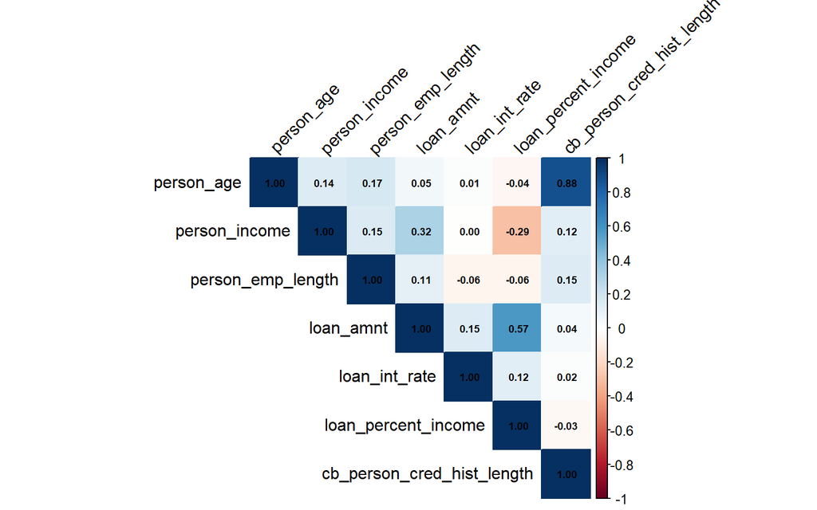

```r
corrplot(
  cor_matrix,
  method = "color",
  type = "upper",
  addCoef.col = "black",
  tl.col = "black",
  tl.srt = 45,
  number.cex = 0.6
)
```

## 5.13 Selected correlations among numerical variables

The notebook plotted an object called `correlations` without a visible definition. It is defined here from `cor_matrix` (computed above) for a set of variable pairs, so the plot always reflects the data. The pairs shown are the ones selected for this report.

```r
selected_pairs <- data.frame(
  Var1 = c("person_age", "person_income", "loan_amnt",
           "person_income", "person_age", "loan_int_rate"),
  Var2 = c("cb_person_cred_hist_length", "loan_amnt", "loan_percent_income",
           "loan_percent_income", "person_emp_length", "loan_percent_income"),
  stringsAsFactors = FALSE
)

correlations <- data.frame(
  Relationship = paste(selected_pairs$Var1, "vs", selected_pairs$Var2),
  Correlation  = unname(mapply(
    function(a, b) cor_matrix[a, b],
    selected_pairs$Var1, selected_pairs$Var2
  )),
  stringsAsFactors = FALSE,
  row.names = NULL
)

correlations$Relationship <- factor(
  correlations$Relationship,
  levels = rev(correlations$Relationship)
)

print(correlations)
```

```
##                               Relationship Correlation
## 1 person_age vs cb_person_cred_hist_length   0.8782405
## 2               person_income vs loan_amnt   0.3167319
## 3         loan_amnt vs loan_percent_income   0.5726316
## 4     person_income vs loan_percent_income  -0.2947660
## 5          person_age vs person_emp_length   0.1724812
## 6     loan_int_rate vs loan_percent_income   0.1201111
```

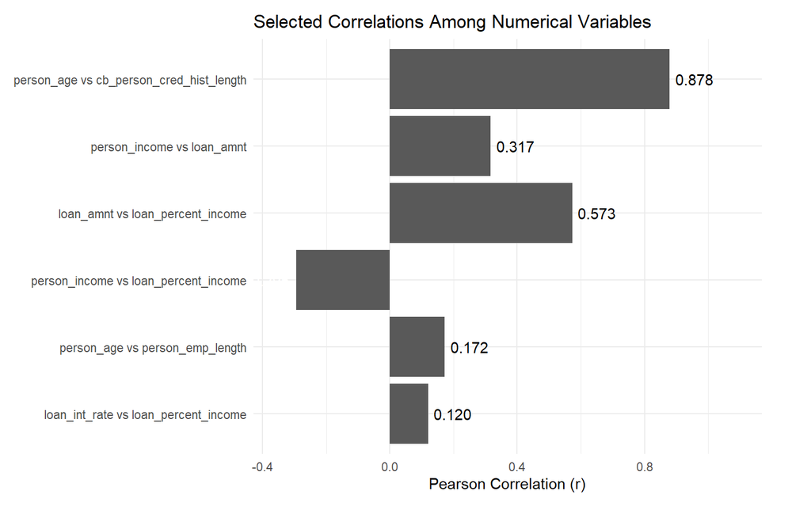

```r
ggplot(correlations, aes(x = Relationship, y = Correlation)) +
  geom_col() +
  geom_text(
    aes(
      label = sprintf("%.3f", Correlation),
      hjust = ifelse(Correlation < 0, 1.15, -0.15),
      color = Correlation < 0
    )
  ) +
  scale_color_manual(
    values = c("TRUE" = "white", "FALSE" = "black"),
    guide = "none"
  ) +
  coord_flip(clip = "off") +
  scale_y_continuous(
    limits = c(-0.4, 1.0),
    expand = expansion(mult = c(0.02, 0.12))
  ) +
  labs(
    title = "Selected Correlations Among Numerical Variables",
    x = NULL,
    y = "Pearson Correlation (r)"
  ) +
  theme_minimal() +
  theme(plot.margin = ggplot2::margin(10, 35, 10, 10))
```

# 6 Statistical Analysis and Data Preparation

## 6.1 Missing-value treatment: preliminary median imputation

Two variables contain missing values: `person_emp_length` and `loan_int_rate`. This chunk fills them with the **full-data** median on a separate copy (`loan_imputed`) so that descriptive statistics and the chi-square tests can use every row. It is **not** used for modelling: the models use training-set medians only (see the Logistic Regression section) to avoid information leaking from the test set.

```r
# Create a separate dataset for missing-value treatment
loan_imputed <- loan_clean

# Check missing values before treatment
cat("Missing values before treatment:\n")
```

```
## Missing values before treatment:
```

```r
print(colSums(is.na(loan_imputed)))
```

```
##                 person_age              person_income
##                          0                          0
##      person_home_ownership          person_emp_length
##                          0                        887
##                loan_intent                 loan_grade
##                          0                          0
##                  loan_amnt              loan_int_rate
##                          0                       3094
##                loan_status        loan_percent_income
##                          0                          0
##  cb_person_default_on_file cb_person_cred_hist_length
##                          0                          0
```

```r
# 1. Fill missing employment length using the median
employment_median_all <- median(loan_imputed$person_emp_length, na.rm = TRUE)
loan_imputed$person_emp_length[is.na(loan_imputed$person_emp_length)] <-
  employment_median_all

# 2. Fill missing interest rate using the median
interest_median_all <- median(loan_imputed$loan_int_rate, na.rm = TRUE)
loan_imputed$loan_int_rate[is.na(loan_imputed$loan_int_rate)] <-
  interest_median_all

# Check missing values after treatment
cat("\nMissing values after treatment:\n")
```

```
##
## Missing values after treatment:
```

```r
print(colSums(is.na(loan_imputed)))
```

```
##                 person_age              person_income
##                          0                          0
##      person_home_ownership          person_emp_length
##                          0                          0
##                loan_intent                 loan_grade
##                          0                          0
##                  loan_amnt              loan_int_rate
##                          0                          0
##                loan_status        loan_percent_income
##                          0                          0
##  cb_person_default_on_file cb_person_cred_hist_length
##                          0                          0
```

```r
cat("\nDataset dimensions after imputation:\n")
```

```
##
## Dataset dimensions after imputation:
```

```r
print(dim(loan_imputed))
```

```
## [1] 32409    12
```

```r
cat("\nMedian employment length used:", employment_median_all, "\n")
```

```
##
## Median employment length used: 4
```

```r
cat("Median interest rate used:", interest_median_all, "\n")
```

```
## Median interest rate used: 10.99
```

```r
# Confirm no missing values remain
stopifnot(sum(is.na(loan_imputed)) == 0)

# Confirm duplicate rows have not been introduced
cat("Duplicate rows:", sum(duplicated(loan_imputed)), "\n")
```

```
## Duplicate rows: 0
```

```r
# Final structure
str(loan_imputed)
```

```
## 'data.frame':    32409 obs. of  12 variables:
##  $ person_age                : int  21 25 23 24 21 26 24 24 21 22 ...
##  $ person_income             : int  9600 9600 65500 54400 9900 77100 78956 83000 10000 85000 ...
##  $ person_home_ownership     : Factor w/ 4 levels "MORTGAGE","OTHER",..: 3 1 4 4 3 4 4 4 3 4 ...
##  $ person_emp_length         : num  5 1 4 8 2 8 5 8 6 6 ...
##  $ loan_intent               : Factor w/ 6 levels "DEBTCONSOLIDATION",..: 2 4 4 4 6 2 4 5 6 6 ...
##  $ loan_grade                : Factor w/ 7 levels "A","B","C","D",..: 2 3 3 3 1 2 2 1 4 2 ...
##  $ loan_amnt                 : int  1000 5500 35000 35000 2500 35000 35000 35000 1600 35000 ...
##  $ loan_int_rate             : num  11.14 12.87 15.23 14.27 7.14 ...
##  $ loan_status               : Factor w/ 2 levels "0","1": 1 2 2 2 2 2 2 2 2 2 ...
##  $ loan_percent_income       : num  0.1 0.57 0.53 0.55 0.25 0.45 0.44 0.42 0.16 0.41 ...
##  $ cb_person_default_on_file : Factor w/ 2 levels "N","Y": 1 1 1 2 1 1 1 1 1 1 ...
##  $ cb_person_cred_hist_length: int  2 3 2 4 2 3 4 2 3 4 ...
```

```r
# Final summary
summary(loan_imputed)
```

```
##    person_age    person_income     person_home_ownership person_emp_length
##  Min.   :20.00   Min.   :   4000   MORTGAGE:13366        Min.   : 0.000
##  1st Qu.:23.00   1st Qu.:  38500   OTHER   :  106        1st Qu.: 2.000
##  Median :26.00   Median :  55000   OWN     : 2563        Median : 4.000
##  Mean   :27.73   Mean   :  65894   RENT    :16374        Mean   : 4.761
##  3rd Qu.:30.00   3rd Qu.:  79200                         3rd Qu.: 7.000
##  Max.   :94.00   Max.   :2039784                         Max.   :41.000
##
##             loan_intent   loan_grade   loan_amnt     loan_int_rate
##  DEBTCONSOLIDATION:5189   A:10702    Min.   :  500   Min.   : 5.42
##  EDUCATION        :6409   B:10384    1st Qu.: 5000   1st Qu.: 8.49
##  HOMEIMPROVEMENT  :3594   C: 6436    Median : 8000   Median :10.99
##  MEDICAL          :6042   D: 3619    Mean   : 9592   Mean   :11.01
##  PERSONAL         :5496   E:  963    3rd Qu.:12250   3rd Qu.:13.11
##  VENTURE          :5679   F:  241    Max.   :35000   Max.   :23.22
##                           G:   64
##  loan_status loan_percent_income cb_person_default_on_file
##  0:25321     Min.   :0.0000      N:26680
##  1: 7088     1st Qu.:0.0900      Y: 5729
##              Median :0.1500
##              Mean   :0.1702
##              3rd Qu.:0.2300
##              Max.   :0.8300
##
##  cb_person_cred_hist_length
##  Min.   : 2.000
##  1st Qu.: 3.000
##  Median : 4.000
##  Mean   : 5.811
##  3rd Qu.: 8.000
##  Max.   :30.000
##
```

```r
cat("\nMissing-value treatment completed successfully.\n")
```

```
##
## Missing-value treatment completed successfully.
```

## 6.2 Chi-square tests of association

Each categorical predictor is tested against `loan_status`. A small p-value indicates an association, not causation. Some cells (for example loan grade G and home ownership OTHER) are small, so those results should be read with care.

```r
# Variables to test against loan default
categorical_variables <- c(
  "loan_grade",
  "loan_intent",
  "person_home_ownership",
  "cb_person_default_on_file"
)

# Store results
chi_results <- data.frame(
  Variable = character(),
  Chi_Square = numeric(),
  Degrees_of_Freedom = integer(),
  P_Value = numeric(),
  Conclusion = character(),
  stringsAsFactors = FALSE
)

# Run each chi-square test
for (variable in categorical_variables) {

  contingency_table <- table(
    loan_imputed[[variable]],
    loan_imputed$loan_status
  )

  test_result <- chisq.test(contingency_table)

  conclusion <- if (test_result$p.value < 0.05) {
    "Statistically significant association"
  } else {
    "No statistically significant association"
  }

  chi_results <- rbind(
    chi_results,
    data.frame(
      Variable = variable,
      Chi_Square = unname(test_result$statistic),
      Degrees_of_Freedom = unname(test_result$parameter),
      P_Value = test_result$p.value,
      Conclusion = conclusion,
      stringsAsFactors = FALSE
    )
  )
}

# Display results
chi_results$Chi_Square <- round(chi_results$Chi_Square, 3)
chi_results$P_Value <- signif(chi_results$P_Value, 4)

print(chi_results, row.names = FALSE)
```

```
##                   Variable Chi_Square Degrees_of_Freedom    P_Value
##                 loan_grade   5584.784                  6  0.000e+00
##                loan_intent    519.625                  5 4.632e-110
##      person_home_ownership   1893.770                  3  0.000e+00
##  cb_person_default_on_file   1040.119                  1 3.419e-228
##                             Conclusion
##  Statistically significant association
##  Statistically significant association
##  Statistically significant association
##  Statistically significant association
```

## 6.3 Train-test split: 80:20 stratified sampling

The split is made on `loan_clean` (before any imputation), so no test-set information is used to fill missing values.

```r
model_data <- loan_clean

# Ensure target has the correct class order
model_data$loan_status <- factor(model_data$loan_status, levels = c("0", "1"))

# Reproducible 80:20 stratified split
set.seed(123)

train_index <- createDataPartition(
  model_data$loan_status,
  p = 0.80,
  list = FALSE
)

train_data <- model_data[train_index, ]
test_data  <- model_data[-train_index, ]

# Verify split
cat("Training rows:", nrow(train_data), "\n")
```

```
## Training rows: 25928
```

```r
cat("Testing rows:", nrow(test_data), "\n")
```

```
## Testing rows: 6481
```

```r
cat("\nTraining target distribution (%):\n")
```

```
##
## Training target distribution (%):
```

```r
print(round(prop.table(table(train_data$loan_status)) * 100, 2))
```

```
##
##     0     1
## 78.13 21.87
```

```r
cat("\nTesting target distribution (%):\n")
```

```
##
## Testing target distribution (%):
```

```r
print(round(prop.table(table(test_data$loan_status)) * 100, 2))
```

```
##
##     0     1
## 78.14 21.86
```

```r
cat("\nTrain/test split completed.\n")
```

```
##
## Train/test split completed.
```

# 7 Machine Learning Models

## 7.1 Prepare data and train Logistic Regression

Missing values are filled with medians calculated from the **training** data only, and the same values are applied to the test data.

```r
# 1. Calculate imputation values from training data only
employment_median <- median(train_data$person_emp_length, na.rm = TRUE)
interest_median   <- median(train_data$loan_int_rate, na.rm = TRUE)

# 2. Apply the training medians to both datasets
train_data$person_emp_length[is.na(train_data$person_emp_length)] <- employment_median
test_data$person_emp_length[is.na(test_data$person_emp_length)]    <- employment_median

train_data$loan_int_rate[is.na(train_data$loan_int_rate)] <- interest_median
test_data$loan_int_rate[is.na(test_data$loan_int_rate)]    <- interest_median

# 3. Train Logistic Regression (all other columns are predictors)
logistic_model <- glm(
  loan_status ~ .,
  data = train_data,
  family = binomial(link = "logit")
)

# 4. Display model results
summary(logistic_model)
```

```
##
## Call:
## glm(formula = loan_status ~ ., family = binomial(link = "logit"),
##     data = train_data)
##
## Coefficients:
##                              Estimate Std. Error z value Pr(>|z|)
## (Intercept)                -4.099e+00  1.945e-01 -21.072  < 2e-16 ***
## person_age                 -4.163e-03  6.561e-03  -0.635  0.52575
## person_income               1.640e-06  5.962e-07   2.751  0.00595 **
## person_home_ownershipOTHER  7.714e-01  3.194e-01   2.415  0.01573 *
## person_home_ownershipOWN   -1.787e+00  1.141e-01 -15.669  < 2e-16 ***
## person_home_ownershipRENT   8.091e-01  4.479e-02  18.064  < 2e-16 ***
## person_emp_length          -1.432e-02  5.376e-03  -2.663  0.00774 **
## loan_intentEDUCATION       -8.743e-01  6.412e-02 -13.636  < 2e-16 ***
## loan_intentHOMEIMPROVEMENT  4.334e-02  7.093e-02   0.611  0.54119
## loan_intentMEDICAL         -1.857e-01  6.042e-02  -3.074  0.00212 **
## loan_intentPERSONAL        -6.458e-01  6.556e-02  -9.850  < 2e-16 ***
## loan_intentVENTURE         -1.107e+00  6.896e-02 -16.060  < 2e-16 ***
## loan_gradeB                 1.777e-01  7.114e-02   2.498  0.01247 *
## loan_gradeC                 4.859e-01  1.010e-01   4.812 1.49e-06 ***
## loan_gradeD                 2.532e+00  1.237e-01  20.470  < 2e-16 ***
## loan_gradeE                 2.759e+00  1.608e-01  17.155  < 2e-16 ***
## loan_gradeF                 3.278e+00  2.387e-01  13.734  < 2e-16 ***
## loan_gradeG                 6.523e+00  1.049e+00   6.215 5.12e-10 ***
## loan_amnt                  -1.076e-04  5.118e-06 -21.021  < 2e-16 ***
## loan_int_rate               6.182e-02  1.438e-02   4.300 1.71e-05 ***
## loan_percent_income         1.352e+01  2.961e-01  45.657  < 2e-16 ***
## cb_person_default_on_fileY -2.087e-02  5.579e-02  -0.374  0.70839
## cb_person_cred_hist_length -2.369e-03  1.001e-02  -0.237  0.81288
## ---
## Signif. codes:  0 '***' 0.001 '**' 0.01 '*' 0.05 '.' 0.1 ' ' 1
##
## (Dispersion parameter for binomial family taken to be 1)
##
##     Null deviance: 27239  on 25927  degrees of freedom
## Residual deviance: 17530  on 25905  degrees of freedom
## AIC: 17576
##
## Number of Fisher Scoring iterations: 6
```

```r
cat("\nLogistic Regression training completed.\n")
```

```
##
## Logistic Regression training completed.
```

```r
cat("Training rows:", nrow(train_data), "\n")
```

```
## Training rows: 25928
```

```r
cat("Testing rows:", nrow(test_data), "\n")
```

```
## Testing rows: 6481
```

```r
cat("Remaining missing values in training data:", sum(is.na(train_data)), "\n")
```

```
## Remaining missing values in training data: 0
```

```r
cat("Remaining missing values in testing data:", sum(is.na(test_data)), "\n")
```

```
## Remaining missing values in testing data: 0
```

## 7.2 Evaluate Logistic Regression on test data

`actual_status` and `conf_matrix` are created first, and the confusion-matrix plot and metrics are built from them. In the confusion table, rows are predictions and columns are actual classes, with `"1"` (default) as the positive class.

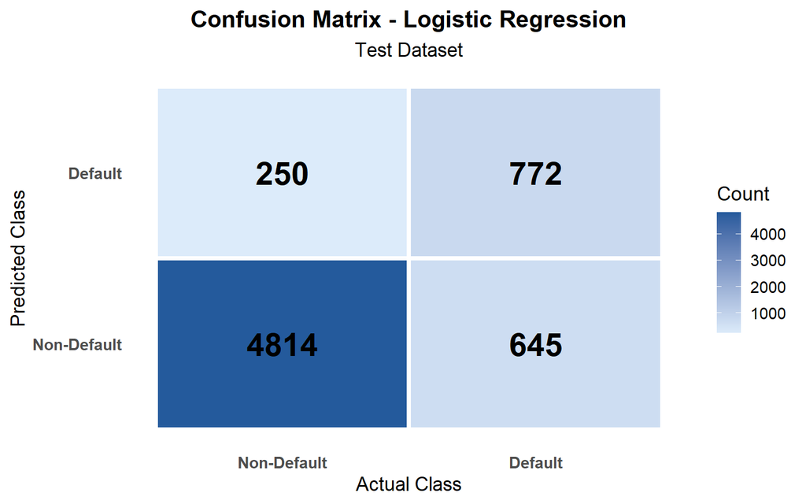

```r
# Predict probability of default (loan_status = 1)
logistic_prob <- predict(logistic_model, newdata = test_data, type = "response")

# Convert probabilities into class predictions using a 0.5 threshold
logistic_pred <- factor(ifelse(logistic_prob >= 0.5, "1", "0"), levels = c("0", "1"))

# Actual classes for the test set (used by every later evaluation)
actual_status <- factor(test_data$loan_status, levels = c("0", "1"))

# Confusion matrix (created BEFORE it is plotted or used for metrics)
conf_matrix <- confusionMatrix(
  data = logistic_pred,
  reference = actual_status,
  positive = "1"
)

# Visual confusion matrix - Logistic Regression
logistic_cm_df <- as.data.frame(conf_matrix$table)
colnames(logistic_cm_df) <- c("Predicted", "Actual", "Count")

ggplot(logistic_cm_df, aes(x = Actual, y = Predicted, fill = Count)) +
  geom_tile(color = "white", linewidth = 1.5) +
  geom_text(aes(label = Count), size = 8, fontface = "bold") +
  scale_fill_gradient(low = "#DCEBFA", high = "#245A9C") +
  scale_x_discrete(labels = c("0" = "Non-Default", "1" = "Default")) +
  scale_y_discrete(labels = c("0" = "Non-Default", "1" = "Default")) +
  labs(
    title = "Confusion Matrix - Logistic Regression",
    subtitle = "Test Dataset",
    x = "Actual Class",
    y = "Predicted Class",
    fill = "Count"
  ) +
  theme_minimal(base_size = 14) +
  theme(
    plot.title = element_text(face = "bold", hjust = 0.5),
    plot.subtitle = element_text(hjust = 0.5),
    axis.text = element_text(face = "bold"),
    panel.grid = element_blank()
  )
```

```r
# Calculate evaluation metrics
cm <- conf_matrix$table

true_negative  <- cm["0", "0"]
false_negative <- cm["0", "1"]
false_positive <- cm["1", "0"]
true_positive  <- cm["1", "1"]

accuracy  <- (true_positive + true_negative) / sum(cm)
precision <- ifelse(
  true_positive + false_positive > 0,
  true_positive / (true_positive + false_positive), 0
)
recall <- ifelse(
  true_positive + false_negative > 0,
  true_positive / (true_positive + false_negative), 0
)
f1_score <- ifelse(
  precision + recall > 0,
  2 * precision * recall / (precision + recall), 0
)

cat("\n--- Logistic Regression Test Metrics ---\n")
```

```
##
## --- Logistic Regression Test Metrics ---
```

```r
cat("Accuracy :", round(accuracy, 4), "\n")
```

```
## Accuracy : 0.8619
```

```r
cat("Precision:", round(precision, 4), "\n")
```

```
## Precision: 0.7554
```

```r
cat("Recall   :", round(recall, 4), "\n")
```

```
## Recall   : 0.5448
```

```r
cat("F1-score :", round(f1_score, 4), "\n")
```

```
## F1-score : 0.633
```

## 7.3 ROC curve and AUC: Logistic Regression

```r
roc_result <- roc(
  response = actual_status,
  predictor = logistic_prob,
  levels = c("0", "1"),
  direction = "<",
  quiet = TRUE
)

auc_value <- as.numeric(auc(roc_result))

cat("Logistic Regression ROC-AUC:", round(auc_value, 4), "\n")
```

```
## Logistic Regression ROC-AUC: 0.8639
```

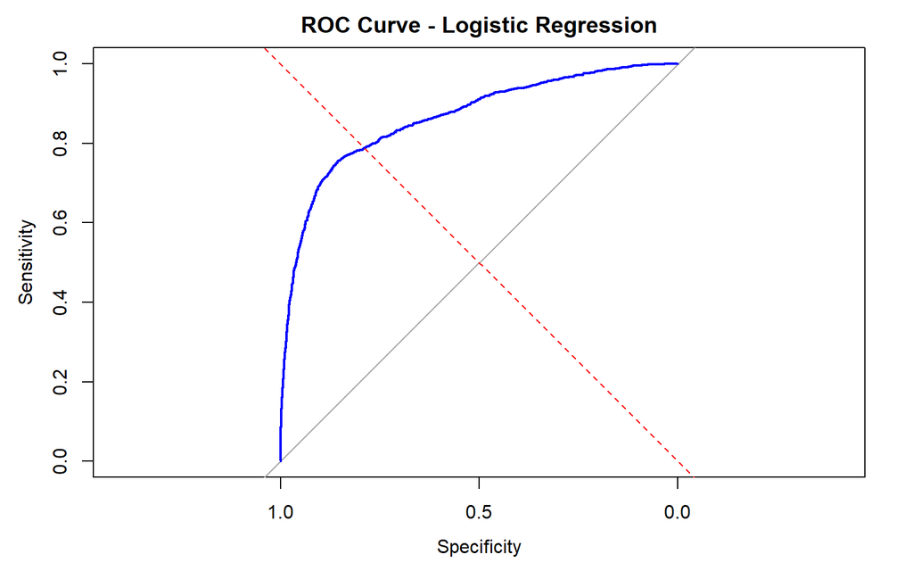

```r
plot(roc_result, main = "ROC Curve - Logistic Regression", col = "blue", lwd = 2)
abline(a = 0, b = 1, lty = 2, col = "red")
```

## 7.4 Train the Random Forest model

```r
set.seed(123)

rf_model <- randomForest(
  loan_status ~ .,
  data = train_data,
  ntree = 300,
  importance = TRUE
)

print(rf_model)
```

```
##
## Call:
##  randomForest(formula = loan_status ~ ., data = train_data, ntree = 300,      importance = TRUE)
##                Type of random forest: classification
##                      Number of trees: 300
## No. of variables tried at each split: 3
##
##         OOB estimate of  error rate: 6.63%
## Confusion matrix:
##       0    1 class.error
## 0 20147  110 0.005430222
## 1  1608 4063 0.283547875
```

```r
cat("\nRandom Forest training completed.\n")
```

```
##
## Random Forest training completed.
```

## 7.5 Evaluate Random Forest on test data

As with Logistic Regression, `rf_conf_matrix` is created before it is plotted or used for metrics. The predicted classes (`rf_pred`) come from the forest’s majority vote, which can differ very slightly from applying a 0.50 cut-off to `rf_prob` (this is why the threshold table later shows a tiny difference at 0.50).

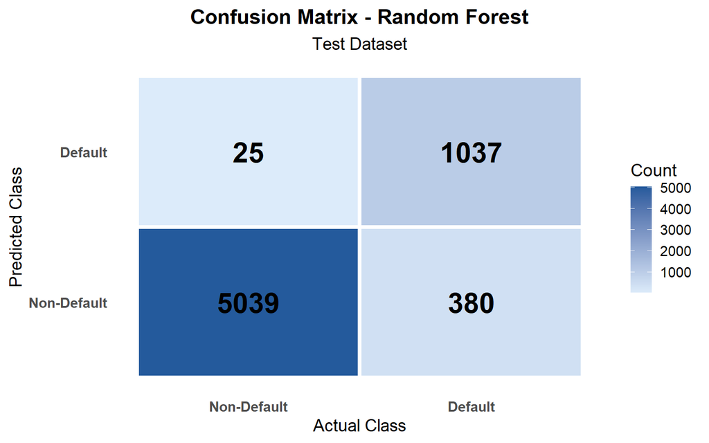

```r
# Predicted probability of default and predicted class
rf_prob <- predict(rf_model, newdata = test_data, type = "prob")[, "1"]
rf_pred <- factor(
  as.character(predict(rf_model, newdata = test_data, type = "response")),
  levels = c("0", "1")
)

# Confusion matrix (created BEFORE it is plotted or used for metrics)
rf_conf_matrix <- confusionMatrix(
  data = rf_pred,
  reference = actual_status,
  positive = "1"
)

# Visual confusion matrix - Random Forest
rf_cm_df <- as.data.frame(rf_conf_matrix$table)
colnames(rf_cm_df) <- c("Predicted", "Actual", "Count")

ggplot(rf_cm_df, aes(x = Actual, y = Predicted, fill = Count)) +
  geom_tile(color = "white", linewidth = 1.5) +
  geom_text(aes(label = Count), size = 8, fontface = "bold") +
  scale_fill_gradient(low = "#DCEBFA", high = "#245A9C") +
  scale_x_discrete(labels = c("0" = "Non-Default", "1" = "Default")) +
  scale_y_discrete(labels = c("0" = "Non-Default", "1" = "Default")) +
  labs(
    title = "Confusion Matrix - Random Forest",
    subtitle = "Test Dataset",
    x = "Actual Class",
    y = "Predicted Class",
    fill = "Count"
  ) +
  theme_minimal(base_size = 14) +
  theme(
    plot.title = element_text(face = "bold", hjust = 0.5),
    plot.subtitle = element_text(hjust = 0.5),
    axis.text = element_text(face = "bold"),
    panel.grid = element_blank()
  )
```

```r
rf_cm <- rf_conf_matrix$table

rf_tn <- rf_cm["0", "0"]
rf_fn <- rf_cm["0", "1"]
rf_fp <- rf_cm["1", "0"]
rf_tp <- rf_cm["1", "1"]

rf_accuracy  <- (rf_tp + rf_tn) / sum(rf_cm)
rf_precision <- rf_tp / (rf_tp + rf_fp)
rf_recall    <- rf_tp / (rf_tp + rf_fn)
rf_f1        <- 2 * rf_precision * rf_recall / (rf_precision + rf_recall)

cat("\n--- Random Forest Test Metrics ---\n")
```

```
##
## --- Random Forest Test Metrics ---
```

```r
cat("Accuracy :", round(rf_accuracy, 4), "\n")
```

```
## Accuracy : 0.9375
```

```r
cat("Precision:", round(rf_precision, 4), "\n")
```

```
## Precision: 0.9765
```

```r
cat("Recall   :", round(rf_recall, 4), "\n")
```

```
## Recall   : 0.7318
```

```r
cat("F1-score :", round(rf_f1, 4), "\n")
```

```
## F1-score : 0.8366
```

```r
rf_roc <- roc(
  response = actual_status,
  predictor = rf_prob,
  levels = c("0", "1"),
  direction = "<",
  quiet = TRUE
)

rf_auc <- as.numeric(auc(rf_roc))
cat("ROC-AUC  :", round(rf_auc, 4), "\n")
```

```
## ROC-AUC  : 0.9384
```

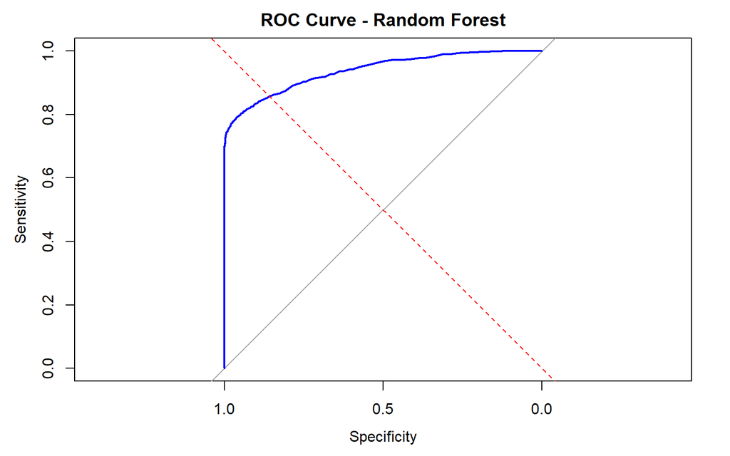

```r
plot(rf_roc, main = "ROC Curve - Random Forest", col = "blue", lwd = 2)
abline(a = 0, b = 1, lty = 2, col = "red")
```

## 7.6 Model performance comparison

```r
model_comparison <- data.frame(
  Model     = c("Logistic Regression", "Random Forest"),
  Accuracy  = c(accuracy, rf_accuracy),
  Precision = c(precision, rf_precision),
  Recall    = c(recall, rf_recall),
  F1_Score  = c(f1_score, rf_f1),
  ROC_AUC   = c(auc_value, rf_auc)
)

comparison_print <- model_comparison
comparison_print[, -1] <- round(comparison_print[, -1], 4)
print(comparison_print, row.names = FALSE)
```

```
##                Model Accuracy Precision Recall F1_Score ROC_AUC
##  Logistic Regression   0.8619    0.7554 0.5448   0.6330  0.8639
##        Random Forest   0.9375    0.9765 0.7318   0.8366  0.9384
```

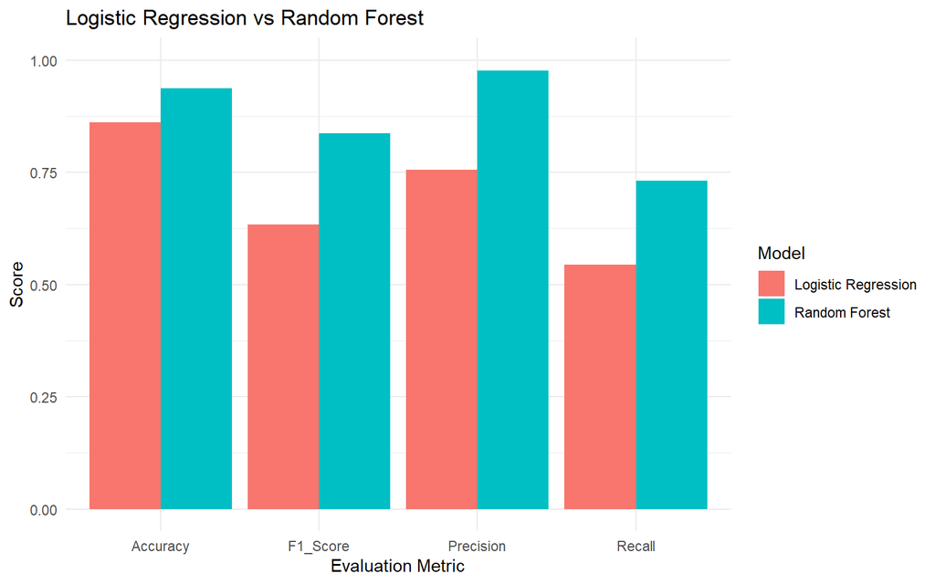

```r
# Plot comparison
comparison_long <- data.frame(
  Model = rep(model_comparison$Model, each = 4),
  Metric = rep(c("Accuracy", "Precision", "Recall", "F1_Score"), 2),
  Score = c(
    accuracy, precision, recall, f1_score,
    rf_accuracy, rf_precision, rf_recall, rf_f1
  )
)

ggplot(comparison_long, aes(x = Metric, y = Score, fill = Model)) +
  geom_col(position = "dodge") +
  labs(
    title = "Logistic Regression vs Random Forest",
    x = "Evaluation Metric",
    y = "Score"
  ) +
  ylim(0, 1) +
  theme_minimal()
```

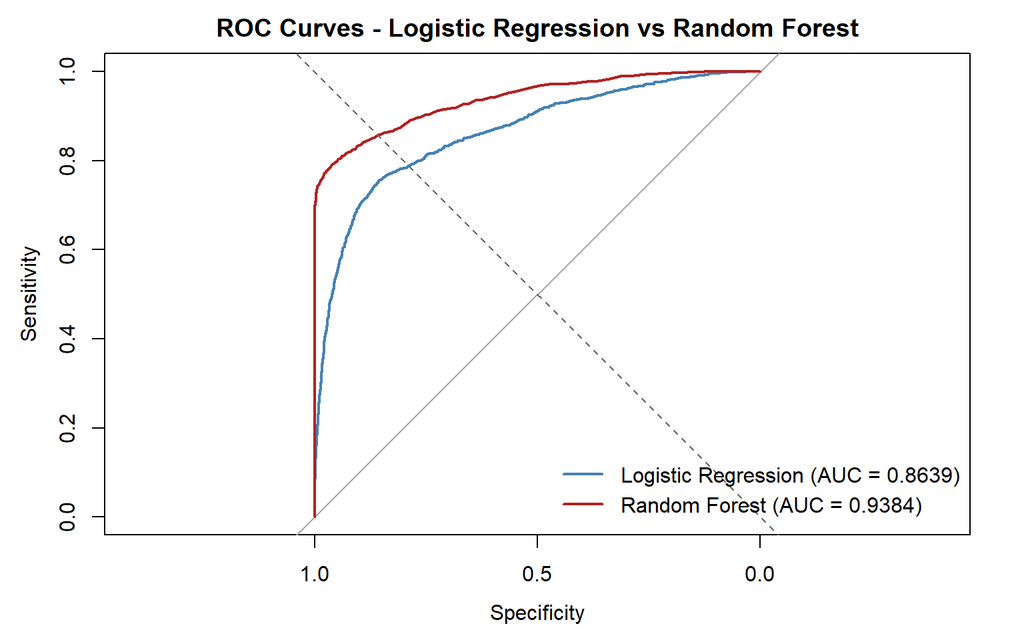

```r
# Both ROC curves on one plot
plot(roc_result, col = "steelblue", lwd = 2,
     main = "ROC Curves - Logistic Regression vs Random Forest")
plot(rf_roc, col = "firebrick", lwd = 2, add = TRUE)
abline(a = 0, b = 1, lty = 2, col = "grey40")
legend(
  "bottomright",
  legend = c(
    paste0("Logistic Regression (AUC = ", round(auc_value, 4), ")"),
    paste0("Random Forest (AUC = ", round(rf_auc, 4), ")")
  ),
  col = c("steelblue", "firebrick"), lwd = 2, bty = "n"
)
```

## 7.7 Feature importance of the Random Forest

```r
importance_values <- importance(rf_model)

importance_df <- data.frame(
  Feature = rownames(importance_values),
  Importance = importance_values[, "MeanDecreaseGini"]
)

importance_df <- importance_df[order(importance_df$Importance, decreasing = TRUE), ]

print(importance_df, row.names = FALSE)
```

```
##                     Feature Importance
##         loan_percent_income  1924.0951
##               person_income  1280.4665
##                  loan_grade  1044.5926
##               loan_int_rate   957.0813
##       person_home_ownership   944.5979
##                 loan_intent   747.2400
##                   loan_amnt   613.5121
##           person_emp_length   547.3614
##                  person_age   381.5152
##  cb_person_cred_hist_length   287.6509
##   cb_person_default_on_file    80.5233
```

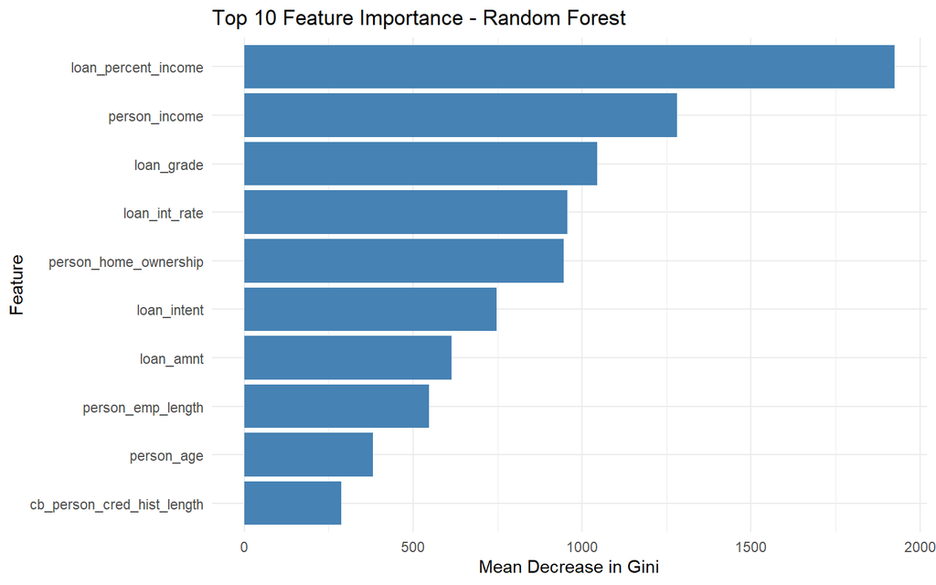

```r
# Visualize the top 10 important features
top_features <- head(importance_df, 10)

ggplot(top_features, aes(x = reorder(Feature, Importance), y = Importance)) +
  geom_col(fill = "steelblue") +
  coord_flip() +
  labs(
    title = "Top 10 Feature Importance - Random Forest",
    x = "Feature",
    y = "Mean Decrease in Gini"
  ) +
  theme_minimal()
```

Feature importance shows which variables the forest relied on most; it does not show that a variable causes default.

## 7.8 Final model validation checks

```r
cat("===== FINAL PROJECT VALIDATION =====\n\n")
```

```
## ===== FINAL PROJECT VALIDATION =====
```

```r
cat("Training rows:", nrow(train_data), "\n")
```

```
## Training rows: 25928
```

```r
cat("Testing rows:", nrow(test_data), "\n")
```

```
## Testing rows: 6481
```

```r
cat("Missing values in training data:", sum(is.na(train_data)), "\n")
```

```
## Missing values in training data: 0
```

```r
cat("Missing values in testing data:", sum(is.na(test_data)), "\n")
```

```
## Missing values in testing data: 0
```

```r
cat("\nTest prediction count:", length(rf_pred), "\n")
```

```
##
## Test prediction count: 6481
```

```r
cat("Actual test labels:", length(actual_status), "\n")
```

```
## Actual test labels: 6481
```

```r
cat("\n===== RANDOM FOREST RESULTS (threshold from majority vote) =====\n")
```

```
##
## ===== RANDOM FOREST RESULTS (threshold from majority vote) =====
```

```r
cat("Accuracy :", round(rf_accuracy * 100, 2), "%\n")
```

```
## Accuracy : 93.75 %
```

```r
cat("Precision:", round(rf_precision * 100, 2), "%\n")
```

```
## Precision: 97.65 %
```

```r
cat("Recall   :", round(rf_recall * 100, 2), "%\n")
```

```
## Recall   : 73.18 %
```

```r
cat("F1-score :", round(rf_f1, 4), "\n")
```

```
## F1-score : 0.8366
```

```r
cat("ROC-AUC  :", round(rf_auc, 4), "\n")
```

```
## ROC-AUC  : 0.9384
```

```r
stopifnot(
  sum(is.na(train_data)) == 0,
  sum(is.na(test_data)) == 0,
  length(rf_pred) == nrow(test_data),
  length(rf_prob) == nrow(test_data),
  identical(levels(actual_status), c("0", "1")),
  identical(levels(rf_pred), c("0", "1"))
)

cat("\nAll final validation checks passed.\n")
```

```
##
## All final validation checks passed.
```

# 8 Experiments

## 8.1 Random Forest threshold-tuning experiment

The default decision threshold is 0.50. Lowering it flags more loans as defaults, which usually raises recall and lowers precision.

```r
thresholds <- c(0.50, 0.45, 0.40, 0.35, 0.30, 0.25, 0.20)

threshold_results <- data.frame()

for (threshold in thresholds) {

  pred <- factor(
    ifelse(rf_prob >= threshold, "1", "0"),
    levels = c("0", "1")
  )

  cm_t <- confusionMatrix(
    data = pred,
    reference = actual_status,
    positive = "1"
  )

  threshold_results <- rbind(
    threshold_results,
    data.frame(
      Threshold = threshold,
      Accuracy  = unname(cm_t$overall["Accuracy"]),
      Precision = unname(cm_t$byClass["Pos Pred Value"]),
      Recall    = unname(cm_t$byClass["Sensitivity"]),
      F1        = unname(cm_t$byClass["F1"])
    )
  )
}

print(round(threshold_results, 4), row.names = FALSE)
```

```
##  Threshold Accuracy Precision Recall     F1
##       0.50   0.9377    0.9765 0.7325 0.8371
##       0.45   0.9384    0.9661 0.7445 0.8410
##       0.40   0.9364    0.9467 0.7516 0.8379
##       0.35   0.9329    0.9126 0.7664 0.8331
##       0.30   0.9262    0.8654 0.7848 0.8231
##       0.25   0.9114    0.7905 0.8095 0.7999
##       0.20   0.8824    0.6907 0.8370 0.7569
```

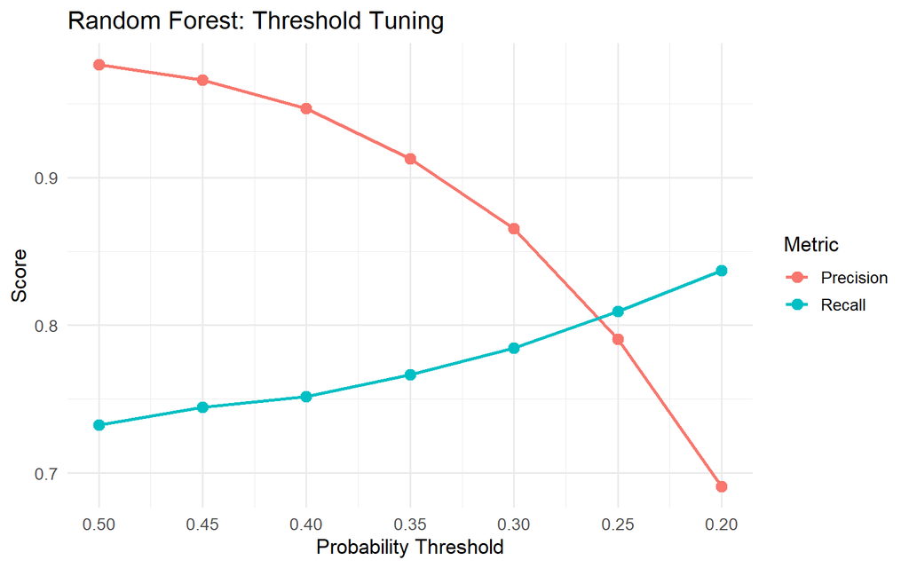

```r
# Visualize recall and precision trade-off
threshold_plot <- rbind(
  data.frame(
    Threshold = threshold_results$Threshold,
    Metric = "Recall",
    Value = threshold_results$Recall
  ),
  data.frame(
    Threshold = threshold_results$Threshold,
    Metric = "Precision",
    Value = threshold_results$Precision
  )
)

ggplot(threshold_plot, aes(x = Threshold, y = Value, color = Metric)) +
  geom_line(linewidth = 1) +
  geom_point(size = 3) +
  scale_x_reverse(breaks = thresholds) +
  labs(
    title = "Random Forest: Threshold Tuning",
    x = "Probability Threshold",
    y = "Score",
    color = "Metric"
  ) +
  theme_minimal(base_size = 13)
```

> **Limitation:** the threshold of 0.40 was chosen after looking at the **test-set** results above. The 0.40 figures are therefore an experiment, not an unbiased estimate of future performance. A stricter design would choose the threshold on a separate validation set and evaluate it once on an untouched test set.

## 8.2 Class-weighted Random Forest experiment

```r
set.seed(123)

rf_weighted <- randomForest(
  loan_status ~ .,
  data = train_data,
  ntree = 500,
  importance = TRUE,
  classwt = c("0" = 1, "1" = 2)
)

# Default probabilities on the same test set
rf_weighted_prob <- predict(rf_weighted, newdata = test_data, type = "prob")[, "1"]

# Evaluate using the same 0.5 threshold
rf_weighted_pred <- factor(
  ifelse(rf_weighted_prob >= 0.5, "1", "0"),
  levels = c("0", "1")
)

weighted_cm <- confusionMatrix(
  data = rf_weighted_pred,
  reference = actual_status,
  positive = "1"
)

print(weighted_cm)
```

```
## Confusion Matrix and Statistics
##
##           Reference
## Prediction    0    1
##          0 5040  388
##          1   24 1029
##
##                Accuracy : 0.9364
##                  95% CI : (0.9302, 0.9422)
##     No Information Rate : 0.7814
##     P-Value [Acc > NIR] : < 2.2e-16
##
##                   Kappa : 0.795
##
##  Mcnemar's Test P-Value : < 2.2e-16
##
##             Sensitivity : 0.7262
##             Specificity : 0.9953
##          Pos Pred Value : 0.9772
##          Neg Pred Value : 0.9285
##              Prevalence : 0.2186
##          Detection Rate : 0.1588
##    Detection Prevalence : 0.1625
##       Balanced Accuracy : 0.8607
##
##        'Positive' Class : 1
##
```

```r
cat("\nClass-Weighted Random Forest Metrics\n")
```

```
##
## Class-Weighted Random Forest Metrics
```

```r
cat("Accuracy :", round(weighted_cm$overall["Accuracy"], 4), "\n")
```

```
## Accuracy : 0.9364
```

```r
cat("Precision:", round(weighted_cm$byClass["Pos Pred Value"], 4), "\n")
```

```
## Precision: 0.9772
```

```r
cat("Recall   :", round(weighted_cm$byClass["Sensitivity"], 4), "\n")
```

```
## Recall   : 0.7262
```

```r
cat("F1-score :", round(weighted_cm$byClass["F1"], 4), "\n")
```

```
## F1-score : 0.8332
```

## 8.3 Small category counts

Some categories are small, so their default rates are less reliable.

```r
cat("\nLoan Grade Counts:\n")
```

```
##
## Loan Grade Counts:
```

```r
print(table(loan_clean$loan_grade))
```

```
##
##     A     B     C     D     E     F     G
## 10702 10384  6436  3619   963   241    64
```

```r
cat("\nHome Ownership Counts:\n")
```

```
##
## Home Ownership Counts:
```

```r
print(table(loan_clean$person_home_ownership))
```

```
##
## MORTGAGE    OTHER      OWN     RENT
##    13366      106     2563    16374
```

```r
cat("\nDefault Rates by Loan Grade (%):\n")
```

```
##
## Default Rates by Loan Grade (%):
```

```r
print(round(
  prop.table(table(loan_clean$loan_grade, loan_clean$loan_status), margin = 1)[, "1"] * 100,
  2
))
```

```
##     A     B     C     D     E     F     G
##  9.96 16.32 20.76 59.05 64.49 70.54 98.44
```

```r
cat("\nDefault Rates by Home Ownership (%):\n")
```

```
##
## Default Rates by Home Ownership (%):
```

```r
print(round(
  prop.table(
    table(loan_clean$person_home_ownership, loan_clean$loan_status),
    margin = 1
  )[, "1"] * 100,
  2
))
```

```
## MORTGAGE    OTHER      OWN     RENT
##    12.62    31.13     7.49    31.61
```

## 8.4 Random Forest evaluation at threshold 0.40

```r
chosen_threshold <- 0.40

rf_tuned_pred <- factor(
  ifelse(rf_prob >= chosen_threshold, "1", "0"),
  levels = c("0", "1")
)

rf_tuned_cm <- confusionMatrix(
  data = rf_tuned_pred,
  reference = actual_status,
  positive = "1"
)

print(rf_tuned_cm)
```

```
## Confusion Matrix and Statistics
##
##           Reference
## Prediction    0    1
##          0 5004  352
##          1   60 1065
##
##                Accuracy : 0.9364
##                  95% CI : (0.9302, 0.9422)
##     No Information Rate : 0.7814
##     P-Value [Acc > NIR] : < 2.2e-16
##
##                   Kappa : 0.799
##
##  Mcnemar's Test P-Value : < 2.2e-16
##
##             Sensitivity : 0.7516
##             Specificity : 0.9882
##          Pos Pred Value : 0.9467
##          Neg Pred Value : 0.9343
##              Prevalence : 0.2186
##          Detection Rate : 0.1643
##    Detection Prevalence : 0.1736
##       Balanced Accuracy : 0.8699
##
##        'Positive' Class : 1
##
```

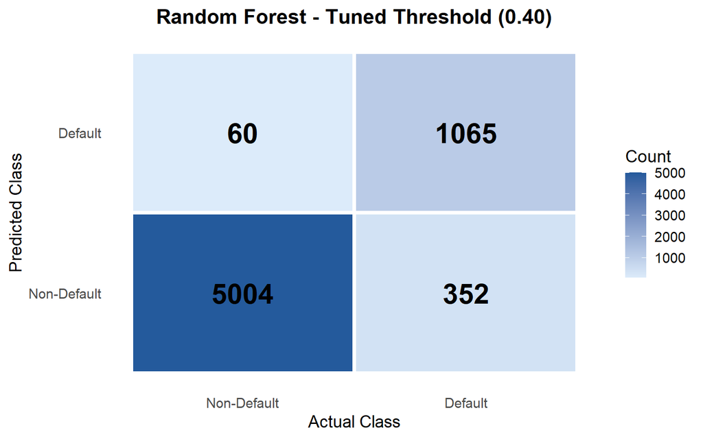

```r
# Confusion matrix as a visual plot
rf_tuned_df <- as.data.frame(rf_tuned_cm$table)
colnames(rf_tuned_df) <- c("Predicted", "Actual", "Count")

ggplot(rf_tuned_df, aes(x = Actual, y = Predicted, fill = Count)) +
  geom_tile(color = "white", linewidth = 1.5) +
  geom_text(aes(label = Count), size = 8, fontface = "bold") +
  scale_fill_gradient(low = "#DCEBFA", high = "#245A9C") +
  scale_x_discrete(labels = c("0" = "Non-Default", "1" = "Default")) +
  scale_y_discrete(labels = c("0" = "Non-Default", "1" = "Default")) +
  labs(
    title = "Random Forest - Tuned Threshold (0.40)",
    x = "Actual Class",
    y = "Predicted Class",
    fill = "Count"
  ) +
  theme_minimal(base_size = 14) +
  theme(
    plot.title = element_text(face = "bold", hjust = 0.5),
    panel.grid = element_blank()
  )
```

```r
cat("\nThreshold:", chosen_threshold, "\n")
```

```
##
## Threshold: 0.4
```

```r
cat("Accuracy         :", round(rf_tuned_cm$overall["Accuracy"], 4), "\n")
```

```
## Accuracy         : 0.9364
```

```r
cat("Precision        :", round(rf_tuned_cm$byClass["Pos Pred Value"], 4), "\n")
```

```
## Precision        : 0.9467
```

```r
cat("Recall           :", round(rf_tuned_cm$byClass["Sensitivity"], 4), "\n")
```

```
## Recall           : 0.7516
```

```r
cat("F1-score         :", round(rf_tuned_cm$byClass["F1"], 4), "\n")
```

```
## F1-score         : 0.8379
```

```r
cat("Balanced accuracy:", round(rf_tuned_cm$byClass["Balanced Accuracy"], 4), "\n")
```

```
## Balanced accuracy: 0.8699
```

## 8.5 Reported results vs results from this knit

The “Reported” columns are the figures from the original project run. The “This knit” columns are computed live above. Small differences can occur with different R or package versions.

```r
reported_vs_live <- data.frame(
  Model = c("Logistic Regression", "Random Forest (0.50)", "Random Forest (0.40)"),
  Reported_Accuracy  = c(0.8619, 0.9375, 0.9364),
  Knit_Accuracy      = c(accuracy, rf_accuracy, unname(rf_tuned_cm$overall["Accuracy"])),
  Reported_Precision = c(0.7554, 0.9765, 0.9467),
  Knit_Precision     = c(precision, rf_precision, unname(rf_tuned_cm$byClass["Pos Pred Value"])),
  Reported_Recall    = c(0.5448, 0.7318, 0.7516),
  Knit_Recall        = c(recall, rf_recall, unname(rf_tuned_cm$byClass["Sensitivity"])),
  Reported_F1        = c(0.6330, 0.8366, 0.8379),
  Knit_F1            = c(f1_score, rf_f1, unname(rf_tuned_cm$byClass["F1"])),
  Reported_AUC       = c(0.8639, 0.9384, NA),
  Knit_AUC           = c(auc_value, rf_auc, NA)
)

reported_vs_live[, -1] <- round(reported_vs_live[, -1], 4)
print(reported_vs_live, row.names = FALSE)
```

```
##                 Model Reported_Accuracy Knit_Accuracy Reported_Precision
##   Logistic Regression            0.8619        0.8619             0.7554
##  Random Forest (0.50)            0.9375        0.9375             0.9765
##  Random Forest (0.40)            0.9364        0.9364             0.9467
##  Knit_Precision Reported_Recall Knit_Recall Reported_F1 Knit_F1 Reported_AUC
##          0.7554          0.5448      0.5448      0.6330  0.6330       0.8639
##          0.9765          0.7318      0.7318      0.8366  0.8366       0.9384
##          0.9467          0.7516      0.7516      0.8379  0.8379           NA
##  Knit_AUC
##    0.8639
##    0.9384
##        NA
```

# 9 LIME Explainability

LIME fits a simple local model around one test applicant to show which feature ranges pushed the Random Forest towards “default” for that case. Two small S3 methods tell `lime` how to treat a `randomForest` model and how to obtain class probabilities (columns named `"0"` and `"1"`). A seed is set so the explanation can be repeated; LIME samples randomly, so the numbers can still differ slightly between package versions.

```r
# Tell lime how to handle a randomForest classification model
model_type.randomForest <- function(x, ...) {
  "classification"
}

predict_model.randomForest <- function(x, newdata, type, ...) {
  probabilities <- predict(x, newdata = newdata, type = "prob")
  as.data.frame(probabilities, check.names = FALSE)
}

# Register methods for the lime package
registerS3method(
  "model_type",
  "randomForest",
  model_type.randomForest,
  envir = asNamespace("lime")
)

registerS3method(
  "predict_model",
  "randomForest",
  predict_model.randomForest,
  envir = asNamespace("lime")
)

# Prepare training features (exclude target)
lime_train <- train_data[
  , setdiff(names(train_data), "loan_status"),
  drop = FALSE
]

# Create LIME explainer
lime_explainer <- lime::lime(
  x = lime_train,
  model = rf_model,
  bin_continuous = TRUE,
  n_bins = 4,
  quantile_bins = TRUE
)

# Select the first test applicant predicted as default
default_cases <- which(as.character(rf_pred) == "1")

if (length(default_cases) == 0) {
  stop("No applicants predicted as default. Check rf_pred.")
}

case_index <- default_cases[1]

# Extract applicant features (exclude target)
applicant <- test_data[
  case_index,
  setdiff(names(test_data), "loan_status"),
  drop = FALSE
]

# Check predicted class probabilities
check_probs <- predict_model.randomForest(
  rf_model,
  applicant,
  type = "prob"
)

print(check_probs)
```

```
##       0    1
## 20 0.12 0.88
```

```r
if (!all(c("0", "1") %in% names(check_probs))) {
  stop("Expected probability columns named '0' and '1'.")
}

# Generate LIME explanation for the default class
set.seed(123)

lime_explanation <- lime::explain(
  x = applicant,
  explainer = lime_explainer,
  n_features = 6,
  labels = "1"
)

# Display explanation results
lime_results <- as.data.frame(lime_explanation)

print(
  lime_results[
    ,
    c(
      "feature",
      "feature_value",
      "feature_desc",
      "feature_weight",
      "label_prob",
      "model_r2"
    ),
    drop = FALSE
  ]
)
```

```
##                     feature feature_value                       feature_desc
## 1             person_income      10800.00             person_income <= 39000
## 2     person_home_ownership          1.00   person_home_ownership = MORTGAGE
## 3       loan_percent_income          0.16 0.15 < loan_percent_income <= 0.23
## 4             loan_int_rate         10.99      8.49 < loan_int_rate <= 10.99
## 5 cb_person_default_on_file          1.00      cb_person_default_on_file = N
## 6               loan_intent          2.00            loan_intent = EDUCATION
##   feature_weight label_prob  model_r2
## 1     0.17780245       0.88 0.1277161
## 2    -0.07466729       0.88 0.1277161
## 3    -0.07039499       0.88 0.1277161
## 4    -0.04697310       0.88 0.1277161
## 5    -0.04391272       0.88 0.1277161
## 6    -0.03575477       0.88 0.1277161
```

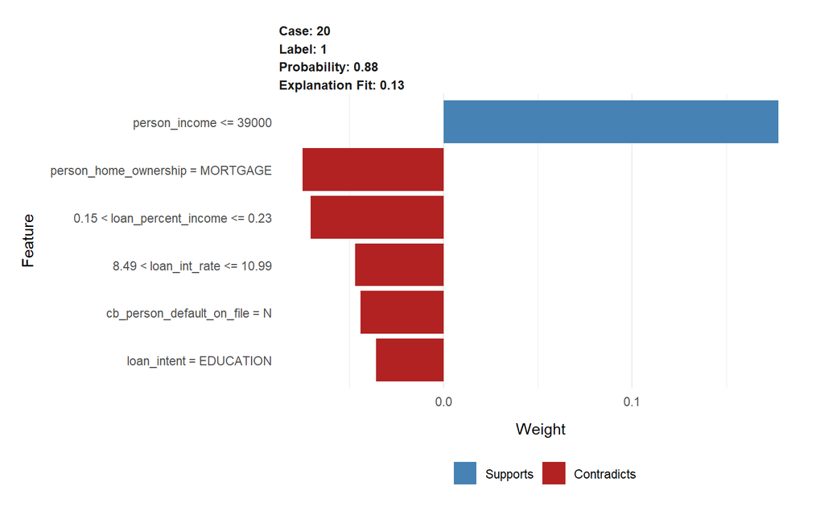

```r
# Plot influential features
plot_features(lime_explanation)
```

```r
# Display prediction and actual outcome
cat("Applicant index:", case_index, "\n")
```

```
## Applicant index: 2
```

```r
cat("Predicted class:", as.character(rf_pred[case_index]), "\n")
```

```
## Predicted class: 1
```

```r
cat("Actual class:", as.character(actual_status[case_index]), "\n")
```

```
## Actual class: 1
```

# 10 Conclusion

**Data preparation.** The original file has 32,581 rows and 12 variables. After removing 165 duplicate rows and a few invalid records (ages above 100 and employment lengths above 50 years), 32,409 rows remain. Default cases make up 7,088 rows (21.87%), so the classes are imbalanced. A stratified 80:20 split gives 25,928 training and 6,481 test records, and missing values in the models are filled with training-set medians.

**Exploratory and statistical findings.** Default rates differ across loan grades, loan purposes, home-ownership groups and previous-default history, and the chi-square tests found a statistically significant association between each categorical variable and loan status. These are associations, not causal relationships.

**Baseline model comparison (reported results).**

| Model | Accuracy | Precision | Recall | F1-score | ROC-AUC |
| --- | --- | --- | --- | --- | --- |
| Logistic Regression | 86.19% | 75.54% | 54.48% | 0.6330 | 0.8639 |
| Random Forest (threshold 0.50) | 93.75% | 97.65% | 73.18% | 0.8366 | 0.9384 |

Random Forest outperformed Logistic Regression on every reported metric.

**Threshold-tuning experiment.** At a threshold of 0.40 the Random Forest reported 93.64% accuracy, 94.67% precision, 75.16% recall, an F1-score of 0.8379 and 86.99% balanced accuracy (confusion matrix: TN = 5,004, FP = 60, FN = 352, TP = 1,065). Compared with 0.50, it catches more defaults at the cost of more false positives. The 0.40 threshold was selected after examining test-set results, so this is an experiment rather than an unbiased final estimate.

**Class-weighted Random Forest.** Giving the default class a weight of 2 did not improve recall in the reported run (about 72.6% versus 73.2% at the baseline).

**LIME.** LIME was applied to one test applicant who was predicted as default and was an actual default. Its explanation fit was low, so the explanation is only indicative.

## 10.1 Limitations and future work

- Default cases are about 21.87% of the cleaned data, so class imbalance remains relevant.
- Loan grade G contains 64 records and the `OTHER` home-ownership group contains 106 records; findings for these small groups need caution.
- Threshold selection used the test set; it should be done on a validation set in future work.
- Associations, feature importance and LIME explanations do not establish causal root causes.
- The LIME example had a low explanation fit.
- Results depend on this dataset and one random split, and may not generalise to other lending populations or time periods.
- Future work: validation-based threshold selection, cross-validation, other imbalance-handling methods, and testing on new data.

# 11 Dataset Source and Project Repository

- **Dataset:** Credit Risk Dataset (`credit_risk_dataset.csv`) - https://www.kaggle.com/datasets/laotse/credit-risk-dataset
- **GitHub repository:** https://github.com/Gautam-2107/Loan-Default-Risk-Analysis

# 12 Reproducibility Instructions

1. Download or clone the project folder so that `Loan_Default_Risk_Analysis_Final.Rmd` and `credit_risk_dataset.csv` are in the **same folder**.
2. Open `Loan_Default_Risk_Analysis_Final.Rmd` in RStudio.
3. Make sure these R packages are installed (the first chunk installs any that are missing, which needs an internet connection): `dplyr`, `ggplot2`, `corrplot`, `caret`, `pROC`, `randomForest`, `lime`.
4. Click **Knit > Knit to HTML**. The output `Loan_Default_Risk_Analysis_Final.html` is created next to the `.Rmd` file.
5. Random seeds are fixed (`set.seed(123)`) before the train-test split, each Random Forest and the LIME explanation, so a re-run with the same R and package versions should reproduce the same results. Training the two Random Forests can take a few minutes.

For version control, keep the `.Rmd`, the `.ipynb` notebook and the documentation in the Git repository and commit major stages (data preparation, EDA, modelling, threshold tuning, final report).